# Are happy songs more popular? A case study with Spotify data

### Introduction

```r
# Start from a clean slate
rm(list = ls())

# Load the packages
library(tidyverse)
library(knitr)      # Tables with kable()
library(lmerTest)   # Linear mixed models, with p-values
library(specr)      # Sensitivity analyses (specification curves)

# Load the dataset
dataset = read.csv("spotify_songs.csv")
```

**General question:**  
Why do people love music?

**Debate:**  
A major debate in the social sciences is whether musical preferences stem from universal biological and cognitive features of our species, or from the specific historical and cultural conventions of genres and scenes. We focus on valence, a song’s musical positivity, because it is a feature about which the two traditions make interestingly divergent predictions.

**Why this matters:**  
If musical appeal relies on universal features, then platforms, artists, and policymakers can rely on general principles of what “works” acoustically. If it is genre-relative, then the same acoustic feature can help one song and hurt another, and any attempt to model taste without accounting for genre will be misleading, both scientifically and in applied settings like recommendation systems.

**Mechanisms (each side):**

*Mechanism 1: Universalist:*  
On the universalist side, researchers have documented cross-cultural regularities in music, suggesting that general psychological mechanisms make certain acoustic properties broadly appealing (Mehr et al., 2019). Applied to valence, this view would argue that positive-sounding acoustic cues (e.g. major mode, consonant harmonies, brighter timbres, moderate-to-fast tempi) engage general affective and reward mechanisms that operate similarly across listeners. Higher-valence songs should therefore be more broadly appealing, regardless of the genre they appear in.

*Mechanism 2: Contextualist:*  
On the contextualist side, sociologists of culture have argued that a song’s success depends on how its features relate to the norms and conventions of its genre: so what “sounds good” is genre-relative rather than universal (Frith, 1996). Applied to valence, this view argues that each genre has developed its own norms about what an emotionally appropriate song sounds like. Dance-oriented genres might reward high positivity because their function is collective celebration; introspective genres like R&B or certain rock traditions value negative valence because melancholy and vulnerability are part of what audiences come to those genres for. On this view, the “right” level of valence is genre-relative, and the same acoustic positivity that helps a pop song succeed can make an R&B track feel awful.

**Point of disagreement:**  
The universalist view predicts that valence has the same positive effect on popularity in every genre, while the contextualist view predicts that the direction of the valence–popularity relationship depends on which genre the song belongs to.

**Research question (conceptual):**  
Is the appeal of musical positivity a general psychological phenomenon, or is it shaped by genre-specific conventions?

**Dataset**

To answer this question, I use the *Spotify Songs* dataset, a publicly available dataset accessed via Kaggle (originally scraped by the user *joebeachcapital* using the Spotify Web API and the `spotifyr` R package). The dataset contains 32,833 rows corresponding to tracks described by 23 variables, covering 6 broad genres (pop, rap, rock, latin, R&B, EDM) further divided into subgenres. Each track was collected because it appeared on a Spotify playlist: the dataset contains 471 playlists in total.

Before starting my analysis, I need to flag some limitations of the data.

First, the tracks are not a representative sample of music, nor even of music on Spotify: they were collected from a curated set of Spotify playlists organized by genre. This means the sample overrepresents tracks that Spotify’s editors chose to include on genre playlists, and underrepresents tracks that exist on the platform but are not playlisted. The sample is therefore biased toward music that is already commercially visible.

Second, the six genre categories (pop, rap, rock, latin, R&B, EDM) are narrow and Western-commercial. Entire musical traditions, like traditional, folk, classical, non-Western popular music, are absent. Any claim I make about “genres” here is really a claim about these six commercial categories.

Third, the `track_popularity` score is a proprietary Spotify metric whose formula is not public. Spotify’s documentation states it is based on total play counts weighted by recency, but the exact weighting is unknown.

**CautionData analysis decision**

Some tracks appear on more than one playlist, and therefore in more than one row: 4,477 rows are a track that already appears elsewhere in the dataset. There are two cases. In 2,448 rows, the same track appears twice *in the same genre* (on two different pop playlists, for instance): these rows are pure copies, which add no information and give the track twice the weight of the others. I remove them. In the other cases, the same track appears in *different* genres (because genre is a playlist-level information). I keep these rows, because the track really belongs to both genres, and dropping one of them would force me to arbitrarily assign each track to a single genre. The dataset now has 30,385 rows. The tracks that remain repeated across genres are by definition by the same artist, which my statistical model takes into account (see the section on random effects).

**Variables**

This dataset lets me answer my conceptual research question because it contains three variables that map, even imperfectly, onto the three concepts at the heart of my question: valence, musical appeal, and genre. I describe each in turn, with the gap between the theoretical construct and the operationalized variable stated explicitly. I then describe the variables I use as controls, and the variables that describe how tracks are grouped in the data.

**`valence` (predictor: operationalization of “valence”).** A continuous variable ranging from 0 to 1, produced by Spotify’s audio analysis algorithm. According to Spotify’s official documentation, valence describes “the musical positiveness conveyed by a track. Tracks with high valence sound more positive (e.g., happy, cheerful, euphoric), while tracks with low valence sound more negative (e.g., sad, depressed, angry).” The score is computed algorithmically from acoustic features (mode, tempo, timbre, harmonic content). Although we lack more specific details, the algorithm was validated by comparing its performance to a sample of human listeners. The algorithm was found to rate a track’s valence similarly to humans, but can sometimes make mistakes. The exact performance of the algorithm is not available, so we cannot correct for its potential bias in the study. For now, let’s just note that the measure of valence mirrors general human perceptions of valence but is imperfect.

*Gap between construct and variable:* the theoretical construct of “musical positivity” in the debate I engage with refers to the general feeling elicited by a track. But Spotify’s `valence` is an algorithmic estimate based on acoustic features alone. It does not capture lyrical content: in theory, a happy melody with dark lyrics would score high; nor video clips and album imagery. It is best understood as a proxy for the *acoustic* dimension of positivity, not the full experience of it.

**`track_popularity` (outcome: operationalization of “musical appeal”).** An integer variable ranging from 0 to 100, computed by Spotify based on total play counts weighted by recency of plays. A first limitation is that the exact weighting method is not reported, but the idea is that recent plays count more than older plays. In sum, this variable does not capture the lifetime popularity of a song, but more how popular it is in recent time.

*Gap between construct and variable:* the theoretical construct I care about is *appeal*: the extent to which listeners find a song attractive. `track_popularity` measures *observed streaming behavior on Spotify*. I believe that, because Spotify is such an important streaming platform, the popularity of a song on Spotify is likely to reflect how much it’s enjoyed. But there are biases: a track’s popularity on Spotify also depends on other things than its pure musical appeal, like what Spotify’s recommendation algorithm surfaces, which artists have marketing and playlist-placement resources, regional availability, and the recency weighting itself, which penalizes older songs regardless of their appeal. A song can be widely appealing without being popular in this operational sense (e.g., an older track no longer being pushed by recommendations), and a song can be popular without being especially appealing (e.g., a track boosted by aggressive playlist placement).

**`playlist_genre` (moderator: operationalization of “genre”).** A categorical variable with six levels: `pop`, `rap`, `rock`, `latin`, `r&b`, `edm`. It reflects the genre label of the *playlist* on which the track was found, not an intrinsic property of the track itself.

*Gap between construct and variable:* “genre” in the theoretical debate refers to a musical community with shared conventions, a history, and an audience with specific expectations. `playlist_genre` is a coarse commercial label assigned at the *playlist* level, meaning a track’s genre in this dataset is determined by which playlist Spotify chose to place it on. Spotify does not share its methodology to attribute playlists to genre, thus the genre variable might have some degree of arbitrariness. Moreover, this list of 6 genres is narrow and Western-centric, as noted above.

**CautionData analysis decision**

There are two variables in the dataset that capture the concept of “genre”: genre and subgenre. I choose to select the genre variable. This is because my hypothesis doesn’t require to go into the details of subgenre. The six genres in the dataset are very different from one another and have very different histories (e.g. rap and EDM), so they are sufficient to test whether strong contextual effects matter. In addition, this decision allows me to have more observations per category, which preserves statistical power.

**`track_album_release_date` (control: operationalization of “the era of a song”).** The release date of the album on which the track appears. I only keep the year, which I call `release_year`, because some dates only contain a year. I use it as a control variable (I explain why in the section on the DAG below).

*Gap between construct and variable:* the construct I want to capture is the era in which a song was produced. But the variable gives the release date of the *album*, not of the song itself. A song from 1985 that was re-released on a 2010 compilation will be dated 2010, which blurs the measure for older songs.

**`instrumentalness` (control: operationalization of “the absence of vocals”).** A continuous variable from 0 to 1, computed by Spotify’s algorithm, which predicts whether a track contains no vocals. The closer to 1, the more likely the track is purely instrumental. I use it as a control variable (I explain why in the section on the DAG below).

*Gap between construct and variable:* the construct I want to capture is whether a song is sung or purely instrumental. But the variable is an algorithmic prediction, not a fact: sounds like “ooh” and “aah” are counted as instrumental, and the algorithm can make mistakes, especially for tracks with very few vocals (which is the case of many EDM tracks).

**`playlist_id` and `track_artist` (grouping variables).** These two variables tell us on which playlist each track was found, and who performs it. They are not variables of interest in themselves, but they describe how tracks are *grouped* in the data. As I explain below, tracks from the same playlist, or by the same artist, are not independent from each other, and my statistical model needs to take this into account.

These variables will allow me to operationalize my research question.

**Research question (operationalized):**  
Does the association between valence and track popularity in the Spotify dataset hold uniformly across genres, or does it vary substantially across them?

**Hypotheses:**

*H1 (universalist):* Valence has a uniform positive association with track popularity across genres: it increases popularity for all genres in my sample. *What would falsify it:* if, in at least one genre, the association between valence and popularity is clearly zero or negative, or if the slopes differ significantly across genres.

*H2 (contextualist):* The valence–popularity relationship varies significantly across genres, with some genres rewarding high valence and others rewarding low valence. *What would falsify it:* if the slope of valence is statistically indistinguishable across genres, or if it goes in the same direction in all genres.

**My favored hypothesis:**

Before running the analysis, I favor the contextualist view. My reasoning is that because specific historical contexts are so determinant in the birth of music genres, listeners do not come to a genre looking for a generic “positive” song: they come with expectations shaped by that genre’s history and function. For instance, someone putting on R&B is often seeking emotional vulnerability, and a high-valence track will feel out of place in that context.

**Intended audience and contribution:**  
I am writing this paper for social scientists interested in the cultural evolution of musical taste with a cognitive approach: researchers like Samuel Mehr and Manvir Singh. I intend to contribute to this debate by testing whether musical features are universally appealing, or whether we need to consider contextual features, using valence as a case in point.

### Data audit: missing values

Before describing my variables, I check whether some values are missing. Missing values matter because R silently removes the rows that contain them when it fits a model. If these rows are not randomly distributed, my results could be biased.

```r
# Keep only the variables I use
dataset_vars = dataset %>%
  select(track_popularity, valence, playlist_genre, track_album_release_date,
         instrumentalness, playlist_id, track_artist)

# Number and share (%) of missing values in each variable, in a table
data.frame(missing = colSums(is.na(dataset_vars)),
           share   = round(colMeans(is.na(dataset_vars)) * 100, 2)) %>%
  kable(col.names = c("Missing values", "Share (%)"))
```

|  | Missing values | Share (%) |
| --- | --- | --- |
| track_popularity | 0 | 0.00 |
| valence | 0 | 0.00 |
| playlist_genre | 0 | 0.00 |
| track_album_release_date | 0 | 0.00 |
| instrumentalness | 0 | 0.00 |
| playlist_id | 0 | 0.00 |
| track_artist | 5 | 0.02 |

**Table 1.** *Missing values in the variables used in the analysis.* Each row reports, for one variable, the number of tracks for which the value is missing, and the corresponding share of the sample. N = 30,385 tracks.

As Table 1 shows, the dataset is almost complete: only `track_artist` has missing values, for 5 tracks out of 30,385.

**CautionData analysis decision**

I remove the 5 tracks with a missing artist: I need to know the artist of each track for my statistical model (see the section on random effects), and these tracks represent a negligible share of the data.

```r
dataset = dataset %>%
  # Remove the tracks with a missing artist
  filter(!is.na(track_artist)) %>%
  # Split the release date ("2019-06-14") into the year ("2019") and the rest ("06-14")
  separate(col = track_album_release_date,
           into = c("release_year", "rest_of_date"),
           sep = "-",
           extra = "merge") %>%
  # The year is stored as text: convert it to a number
  mutate(release_year = as.numeric(release_year))
```

### Descriptive statistics (1): Description of the main variables of interest

```r
# Histogram of popularity (one bar per popularity point), saved as p1
p1 = ggplot(dataset, aes(x = track_popularity)) +
  geom_histogram(binwidth = 1, fill = "darkgreen", alpha = 0.85) +
  labs(title = "Distribution of track popularity",
       x = "Popularity score",
       y = "Number of tracks") +
  theme_minimal()

# Histogram of valence (bars of width 0.01), saved as p2
p2 = ggplot(dataset, aes(x = valence)) +
  geom_histogram(binwidth = 0.01, fill = "darkgreen", alpha = 0.85) +
  labs(title = "Distribution of valence",
       x = "Valence (0 = sad, 1 = happy)",
       y = "Number of tracks") +
  theme_minimal()
```

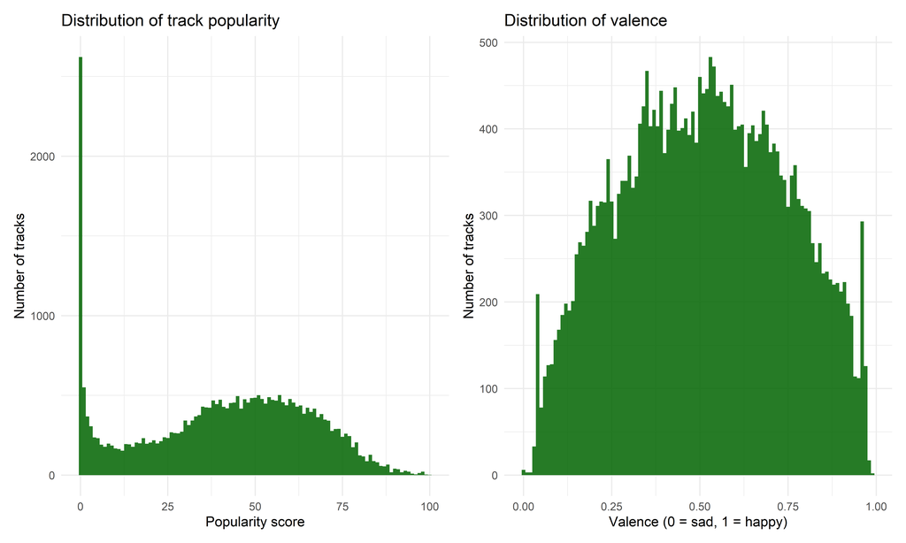

**Figure 1.** *Distributions of track popularity and valence.* Each bar represents the number of tracks (y-axis) falling within a given value range of the variable (x-axis). Left panel: track popularity, a Spotify-computed score from 0 to 100 based on total play counts weighted by recency (bin width = 1). Right panel: valence, a Spotify-computed score from 0 (sad) to 1 (happy) capturing the acoustic positivity of a track (bin width = 0.01). N = 30,380 tracks.

As Figure 1 shows, valence is spread over its whole range, without any unusual shape. Popularity follows a roughly bell-shaped distribution, but with a spike at 0: many tracks have almost no listeners. This makes intuitive sense, since there are many independent artists with a very small audience. These tracks might have a strong influence on my results: I check this later, with Cook’s distance.

Note however that valence is not equally distributed across genres. As one could expect, some genres (e.g. latin) are more positive than others (Figure 2).

```r
# Mean valence in each genre, shown as a bar chart (saved as p3)
p3 = dataset %>%
  group_by(playlist_genre) %>%
  summarise(mean_valence = mean(valence)) %>%
  ggplot(aes(x = playlist_genre, y = mean_valence, fill = playlist_genre)) +
  geom_col(alpha = 0.85) +
  labs(title = "Average valence by genre",
       x = "Genre",
       y = "Mean valence") +
  theme_minimal() +
  theme(legend.position = "none") # the legend is useless: the x-axis already says it
```

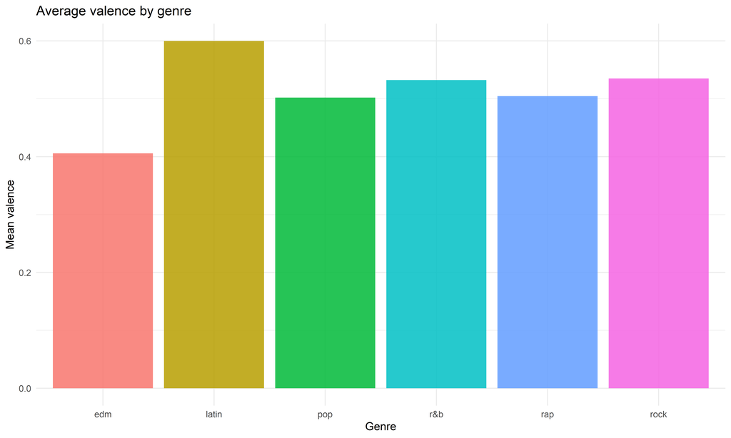

**Figure 2.** *Average valence by genre.* Each bar represents the mean valence (y-axis) of all tracks belonging to a given genre (x-axis). Colors distinguish genres and carry no additional meaning. Latin music has the highest average positivity, and EDM the lowest. N = 30,380 tracks across six genres.

### Descriptive statistics (2): Is valence related to popularity?

Data visualization reveals a slight positive correlation between valence and popularity (Figure 3).

```r
# Scatterplot of popularity against valence, with a regression line (saved as p4)
p4 = ggplot(dataset, aes(x = valence, y = track_popularity)) +
  geom_point(alpha = 0.3, color = "#1DB954") +                  # one green dot per track
  geom_smooth(method = "lm", color = "#191414", fill = "#535353") + # regression line + confidence interval
  labs(title = "Relationship between valence and track popularity",
       x = "Valence (0 = sad, 1 = happy)",
       y = "Track popularity") +
  theme_minimal()
```

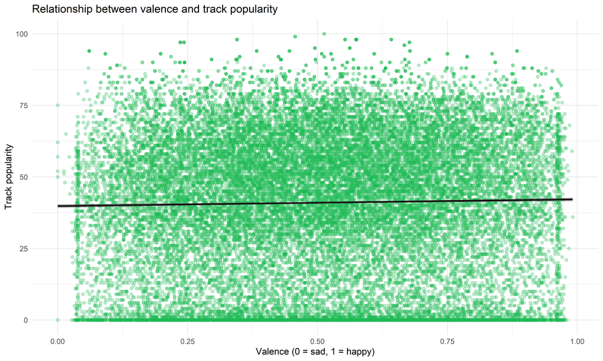

**Figure 3.** *Relationship between valence and track popularity.* Each green dot represents one track, positioned by its valence (x-axis) and its popularity score (y-axis); transparency is used so that overlapping points appear darker. The dark line is the fitted linear regression of popularity on valence (ordinary least squares), and the surrounding gray band is its 95% confidence interval. The slope is slightly positive but the cloud of points is very wide, indicating that valence alone accounts for only a small share of the variation in popularity. N = 30,380 tracks.

However, this relationship likely varies by genre. Different genres serve different emotional functions and attract distinct listener communities, so the valence–popularity relationship could look quite different across musical styles. Each genre contains enough tracks to compare them: between 4,451 and 5,537 tracks per genre.

As expected, the relationship between track valence and popularity varies by genre (Figure 4). In particular, the relationship is especially pronounced for EDM tracks, for which happier songs are more popular. By contrast, the relationship goes in the opposite direction for R&B tracks, with sad R&B songs more popular than happier ones. This makes intuitive sense: EDM songs are usually played in a social, festive setting whereas the R&B genre generally revolves around intimate emotions.

```r
# Same scatterplot, with one color and one regression line per genre (saved as p5)
p5 = ggplot(dataset, aes(x = valence, y = track_popularity, color = playlist_genre)) +
  geom_point(alpha = 0.01) +            # almost invisible dots: we focus on the lines
  geom_smooth(method = "lm", se = FALSE) + # se = FALSE: no confidence interval
  labs(title = "Valence vs track popularity, by genre",
       x = "Valence (0 = sad, 1 = happy)",
       y = "Track popularity",
       color = "Genre") +
  theme_minimal()
```

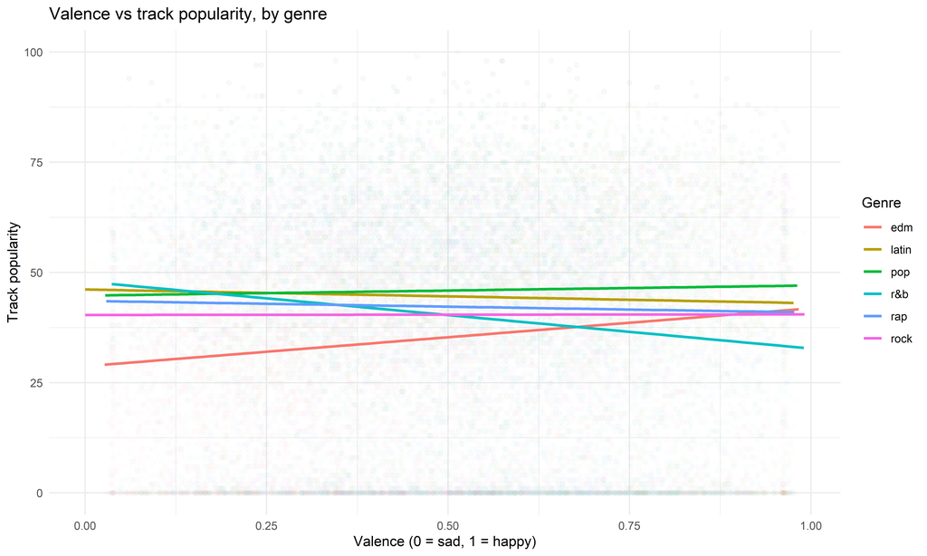

**Figure 4.** *Valence vs. track popularity, by genre.* Each dot represents one track, positioned by its valence (x-axis) and its popularity score (y-axis). Dots are colored by the track’s genre (as coded by `playlist_genre`); transparency is set very low (alpha = 0.01) so that individual points recede and only the density of tracks per region is visible. For each genre, a fitted linear regression line (ordinary least squares) shows the direction and strength of the valence–popularity association within that genre. The 95% confidence intervals are omitted for readability. The slopes vary substantially: EDM shows a clearly positive relationship, while R&B shows a clearly negative one. N = 30,380 tracks across six genres.

At this descriptive stage, the data seem to support my favored hypothesis (H2): the valence–popularity relationship goes in opposite directions in EDM and R&B. But these lines treat every track as an independent observation, and do not take into account any other variable. The next section explains why both of these simplifications are a problem, and how I fix them.

### Choosing the model

To test my hypothesis properly, I need to make four decisions: how to test whether the effect of valence differs across genres, which control variables to include, how to deal with the fact that tracks are grouped in playlists and by artists, and how to choose between several possible models. I take them in turn.

**1. Testing whether the effect of valence differs across genres: an interaction model**

My hypothesis is about an *interaction*: it states that the effect of one variable (valence) depends on the value of another variable (genre). The right tool to test it is a regression with an interaction term, written `valence * playlist_genre` in R. In plain words, this model estimates one slope of valence for each genre, instead of a single slope for everyone.

The output of an interaction model can be tricky to read, so let me explain it once. R chooses one genre as the baseline (here, EDM, the first in alphabetical order). The coefficient of `valence` is then the slope of valence *in EDM only*. Each interaction coefficient (e.g. `valence:playlist_genrer&b`) is the *difference* between the slope of valence in that genre and the slope in EDM. For instance, if the coefficient of `valence` is 4 and the coefficient of `valence:playlist_genrer&b` is −5, the slope of valence in R&B is 4 − 5 = −1.

**CautionData analysis decision**

In RR1, I ran separate regressions within EDM and within R&B, and compared their slopes by eye. The limitation was that this approach does not formally test whether the slopes *differ from each other*. Now, I choose the interaction model instead of the previous approach to do exactly that: each interaction coefficient comes with a p-value that tests whether the slope in that genre differs from the slope in EDM. It also uses all six genres at once, instead of only two.

**CautionData analysis decision**

Genre is a categorical predictor with six levels. I could analyze it with an ANOVA, with a linear model, or both. I use both, because they answer two different questions. The linear model gives me the slope of valence in each genre, which is what my hypothesis is about. But its interaction coefficients only compare each genre to EDM, the baseline: none of them answers the global question “does the slope of valence vary across genres at all?”. The ANOVA answers it, with a single F test for the interaction between valence and genre.

**2. Choosing the control variables: a DAG**

A simple regression of popularity on valence can be misleading if some third variable influences both of them: this variable is called a *confounder*. For instance, if more recent songs were both sadder and more popular, we would find that sadder songs are more popular, even if valence played no role at all. To decide which variables to control for, I drew a DAG (a “directed acyclic graph”): a diagram in which each arrow represents a causal influence that I assume to exist (Figure 5).

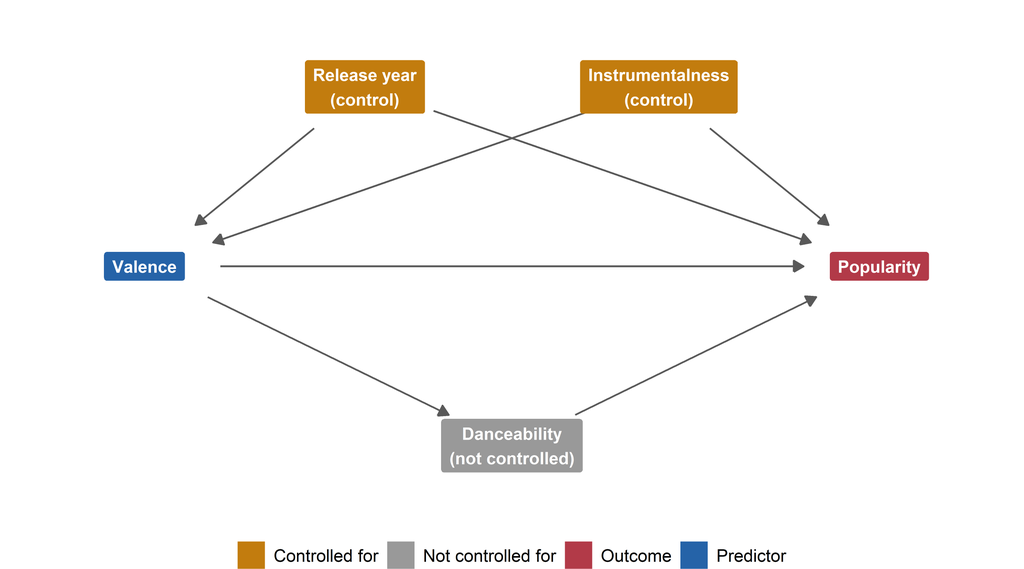

**Figure 5.** *Assumed causal structure (DAG) between valence, popularity, and the other variables.* Each box is a variable, and each arrow is a causal influence that I assume to exist. The predictor (valence) is in blue, the outcome (popularity) in red. Release year and instrumentalness, in orange, are confounders: I control for them. Danceability, in grey, is a possible mediator: I do not control for it. Genre does not appear: it is not a cause of valence or popularity in this diagram, but the variable that I expect to change the strength of the arrow from valence to popularity. Playlists and artists do not appear either: I deal with them separately, with random effects (see below).

The DAG contains two confounders, which I control for. **Release year** influences valence (in this dataset, more recent songs are sadder: the correlation between release year and valence is r = -0.22), and it influences popularity, because Spotify’s popularity score weights recent plays more heavily. **Instrumentalness** influences valence (instrumental tracks get lower valence scores: r = -0.17) and popularity (tracks without vocals are streamed less: r = -0.14). In both cases, valence cannot be the cause: a song’s mood cannot change its release year, nor remove its vocals.

**Danceability** is different. Happy-sounding songs tend to be more danceable (r = 0.33), and danceable songs may be streamed more. In that case, danceability is a *mediator*: it is one of the ways through which valence influences popularity. Controlling for it would remove part of the very effect I want to measure, so I do not include it in my model. Finally, none of my controls is a *collider* (a variable caused by both valence and popularity), which would create a spurious association if I controlled for it. The `dagitty` package confirms which variables I need to control for, given the DAG:

```
{ Instrumentalness, ReleaseYear }
```

The answer is release year and instrumentalness: danceability is not needed. Note that this conclusion is only as good as the DAG itself: if I forgot a confounder, or if danceability is in fact a confounder rather than a mediator, my set of controls would be wrong. I come back to this in the discussion.

**3. Dealing with non-independent observations: random effects**

A linear regression assumes that observations are independent from each other: each track should bring new, separate information. This is clearly not the case here. Tracks from the same playlist share the same audience and the same exposure on Spotify, so their popularity tends to be similar. Tracks by the same artist share the artist’s fame. Ignoring this would be a serious problem for my research question, because genre is assigned *at the playlist level*. When I compare the 5,000 or so R&B tracks to the 5,000 or so EDM tracks, I am really comparing about 80 R&B playlists to about 80 EDM playlists. A regression that treats each track as an independent observation acts as if it had much more evidence than it really has.

There is an even more worrying consequence. Figure 6 zooms in on R&B, the genre where valence seemed to hurt popularity, and shows each playlist as one dot.

```r
# One row per R&B playlist: its average valence, average popularity, and median release year
rnb_playlists = dataset %>%
  filter(playlist_genre == "r&b") %>%
  group_by(playlist_id) %>%
  summarise(mean_valence    = mean(valence),
            mean_popularity = mean(track_popularity),
            median_year     = median(release_year)) %>%
  # Old playlists (median release year before 2010) vs recent ones
  mutate(era = ifelse(median_year < 2010, "Old (before 2010)", "Recent (2010 or later)"))

# One dot per playlist, colored by era (saved as p6)
p6 = ggplot(rnb_playlists, aes(x = mean_valence, y = mean_popularity, color = era)) +
  geom_point(alpha = 0.85) +
  scale_color_manual(values = c("Old (before 2010)" = "#7B3294",
                                "Recent (2010 or later)" = "#E6A700")) +
  labs(title = "R&B playlists: average valence and average popularity",
       x = "Average valence of the playlist",
       y = "Average popularity of the playlist",
       color = "Era of the playlist") +
  theme_minimal()
```

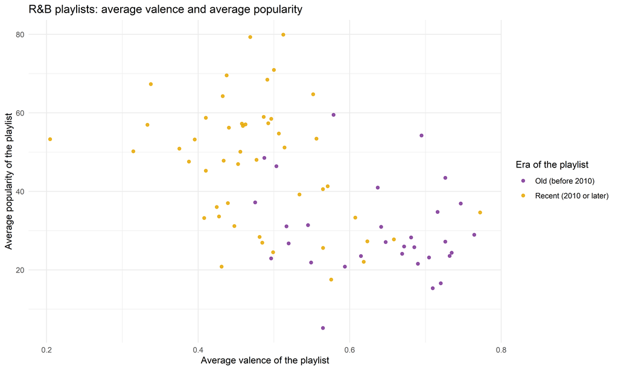

**Figure 6.** *Average valence and average popularity of R&B playlists.* Each dot represents one R&B playlist, positioned by the average valence of its tracks (x-axis) and the average popularity of its tracks (y-axis). The color of each dot indicates the era of the playlist, based on the median release year of its tracks: purple for old playlists (median release year before 2010), yellow for recent ones (2010 or later). N = 80 playlists.

Figure 6 shows that the negative relationship between valence and popularity in R&B is, at least in part, a relationship *between playlists*. The happiest R&B playlists are the old ones (in purple), like playlists of 1990s “New Jack Swing” classics, and they are not very popular, partly because Spotify’s score favors recent plays. The saddest playlists are recent “contemporary R&B” playlists (in yellow), which are very popular. So the sad R&B songs are not necessarily more popular *because* they are sad: they mostly belong to recent, popular playlists. To know whether valence matters in itself, I need to compare songs *within* the same playlist.

This is what a **linear mixed model** does. It is a linear regression that knows which tracks belong to the same group, thanks to *random effects*. A *random intercept* for playlists allows each playlist to have its own average level of popularity: the model then compares songs with their playlist’s average, rather than with all other songs. A *random slope* for valence allows the effect of valence to vary a bit from one playlist to another, so that the genre differences in slopes are tested against the natural variation between playlists, and not only between individual tracks.

**CautionData analysis decision**

I add random effects to my model, because my data is grouped in two ways. For **playlists**, I include a random intercept and a random slope for valence: genre is a playlist-level variable, Figure 6 shows that playlists differ a lot from each other, and each playlist contains enough tracks (66 as a median) to estimate its own slope. For **artists**, I include a random intercept only, and no random slope: 59% of artists have a single track in the data, and it is impossible to estimate how the effect of valence varies within an artist who has only one song.

**4. Choosing between three models: AIC**

I now have a model structure (an interaction between valence and genre, with random effects for playlists and artists), and two control variables justified by my DAG. I compare three possible versions of the model: one without controls (Model 1), one controlling for release year (Model 2), and one controlling for both release year and instrumentalness (Model 3).

```r
# All three models have:
#   - valence * playlist_genre: valence, genre, and their interaction (one slope of valence per genre)
#   - (1 + valence | playlist_id): a random intercept and a random slope of valence per playlist
#   - (1 | track_artist): a random intercept per artist

# Model 1: no controls
model_1 = lmer(track_popularity ~ valence * playlist_genre +
                 (1 + valence | playlist_id) + (1 | track_artist),
               data = dataset)

# Model 2: controlling for release year
model_2 = lmer(track_popularity ~ valence * playlist_genre + release_year +
                 (1 + valence | playlist_id) + (1 | track_artist),
               data = dataset)

# Model 3: controlling for release year and instrumentalness
model_3 = lmer(track_popularity ~ valence * playlist_genre + release_year + instrumentalness +
                 (1 + valence | playlist_id) + (1 | track_artist),
               data = dataset)
```

To choose between them, I use the **AIC** (Akaike Information Criterion). The AIC measures how well a model fits the data, while penalizing it for its complexity (its number of parameters). Adding a variable to a model always improves its fit a little, even if the variable is useless: the AIC only rewards the addition if the improvement is larger than the cost of the extra complexity. A lower AIC indicates a better trade-off between fit and simplicity. The AIC has no meaning on its own: it only allows us to compare models fitted on the same data. As a rule of thumb, a difference of more than 10 points is considered strong evidence in favor of the model with the lower AIC.

Linear mixed models of track popularity, with an interaction between valence and genre.

|  | Model 1 | Model 2 | Model 3 |
| --- | --- | --- | --- |
| Intercept | 33.536*** | 529.734*** | 532.078*** |
|  | (1.481) | (37.339) | (37.290) |
| Valence (slope in EDM) | 5.058*** | 4.848*** | 3.898** |
|  | (1.463) | (1.455) | (1.456) |
| Valence × Latin | -5.011* | -5.071* | -4.222+ |
|  | (2.174) | (2.163) | (2.161) |
| Valence × Pop | -4.254* | -4.468* | -3.783+ |
|  | (2.038) | (2.028) | (2.025) |
| Valence × R&B | -2.774 | -3.027 | -2.136 |
|  | (2.074) | (2.063) | (2.061) |
| Valence × Rap | -4.683* | -4.873* | -4.223* |
|  | (2.052) | (2.042) | (2.038) |
| Valence × Rock | -4.529* | -5.203* | -4.544* |
|  | (2.137) | (2.127) | (2.123) |
| Latin | 9.917*** | 9.543*** | 8.592*** |
|  | (2.172) | (2.208) | (2.202) |
| Pop | 9.379*** | 8.812*** | 7.972*** |
|  | (2.036) | (2.071) | (2.066) |
| R&B | 3.299+ | 2.465 | 1.544 |
|  | (1.833) | (1.853) | (1.850) |
| Rap | 8.531*** | 8.094*** | 7.273** |
|  | (2.179) | (2.227) | (2.219) |
| Rock | 7.901*** | 4.412+ | 3.592 |
|  | (2.279) | (2.343) | (2.334) |
| Release year |  | -0.246*** | -0.247*** |
|  |  | (0.019) | (0.018) |
| Instrumentalness |  |  | -5.275*** |
|  |  |  | (0.622) |
| Num.Obs. | 30380 | 30380 | 30380 |
| R2 Marg. | 0.017 | 0.026 | 0.029 |
| R2 Cond. | 0.477 | 0.496 | 0.495 |
| AIC | 264353.6 | 264180.7 | 264110.8 |

+ p < 0.1, * p < 0.05, ** p < 0.01, *** p < 0.001

**Table 2.** *Linear mixed models predicting track popularity from valence, genre, and their interaction.* Each column is a separate model. Model 1 has no control variables, Model 2 controls for release year, and Model 3 controls for release year and instrumentalness. All three models include a random intercept and a random slope for valence by playlist, and a random intercept by artist. EDM is the baseline genre: “Valence (slope in EDM)” is the effect of valence in EDM, and each “Valence ×” row is the difference between the effect of valence in that genre and in EDM. The rows “Latin”, “Pop”, etc. are the differences in average popularity between each genre and EDM. Cell entries show the estimated coefficient with its standard error in parentheses. Significance stars: + p < .1, * p < .05, ** p < .01, *** p < .001. Below the coefficients: the number of tracks, the marginal and conditional R² (explained below), and the AIC of each model. N = 30,380 tracks.

As Table 2 shows, Model 3 has the lowest AIC, 70 points below Model 2 and 243 points below Model 1. Both control variables improve the model by much more than their cost in complexity, so I select Model 3 for the rest of the analysis.

**CautionData analysis decision**

By default, `lmer()` estimates mixed models with a method called REML, which gives slightly better estimates of the random effects, but makes it invalid to compare models with different control variables using the AIC. So, to compute the AIC of my three models, I re-estimate them with the alternative method (maximum likelihood). The coefficients in Table 2 come from the default (REML) estimation. Note also that I selected my controls in two steps: the DAG told me *which* variables are confounders, and the AIC confirmed that adding them improves the model. The AIC alone cannot tell whether a variable is a confounder: it only measures fit.

### Statistical inference

We now test whether the patterns we observed descriptively hold up once we take into account the grouping of tracks and the control variables.

**NoteNote**

For each model, you need to separate two things: **descriptive results** (the point estimates in *this* sample: the coefficients, the R²) and **inferential results** (what we can say about the population beyond our sample: the p-value, the confidence interval).

Keeping these two levels separate is essential. A large coefficient with a large p-value means that we observe strong effects in our data but that we cannot generalize to the entire population; a small coefficient with a small p-value is a claim we can generalize, but one that may not matter in practice.

| Genre | Slope of valence | 95% CI | p-value |
| --- | --- | --- | --- |
| edm | 3.90 | [1.04, 6.75] | p = .007 |
| latin | -0.32 | [-3.47, 2.82] | p = .840 |
| pop | 0.12 | [-2.68, 2.91] | p = .935 |
| r&b | 1.76 | [-1.13, 4.66] | p = .233 |
| rap | -0.32 | [-3.14, 2.49] | p = .821 |
| rock | -0.65 | [-3.68, 2.39] | p = .677 |

**Table 3.** *Slope of valence in each genre, from Model 3.* Each row reports, for one genre, the estimated change in popularity (on a 0–100 scale) when valence goes from 0 to 1, holding release year and instrumentalness constant, and comparing tracks within the same playlist and artist. The 95% confidence interval and the p-value test whether this slope differs from zero. N = 30,380 tracks.

#### Descriptive results

**Intercept.** The intercept of Model 3 is 532.1. In theory, it is the predicted popularity of an EDM track (the baseline genre) with a valence of 0 and an instrumentalness of 0, released in year 0. Since no song was released in year 0, this number has no real-world meaning: it is just the anchor point of the regression line, and I don’t interpret it further.

**Slope of valence in EDM.** The coefficient of valence is 3.9. Since EDM is the baseline genre, this is the slope of valence in EDM: going from the saddest to the happiest possible EDM track is associated with an increase of about 3.9 popularity points, on a scale from 0 to 100, holding release year and instrumentalness constant.

**Interaction coefficients.** The five interaction coefficients (Table 2) are the differences between the slope of valence in each genre and the slope in EDM. They are all negative: in every other genre, the slope of valence is lower than in EDM.

**Slope of valence in each genre.** Table 3 translates these coefficients into one slope per genre. EDM has by far the largest slope. In R&B, the slope is now 1.76: the strong negative relationship of Figure 4 has disappeared. In the four other genres, the slopes are close to zero, between -0.65 and 0.12.

**R².** Mixed models have two R². The *marginal* R² (0.029) is the share of the variation in popularity explained by the fixed part of the model: valence, genre, their interaction, and the two controls. It is very small: about 2.9%. The *conditional* R² (0.495) also includes the random effects: with the differences between playlists and artists, the model explains about 50% of the variation in popularity. In other words, which playlist a song is on, and who sings it, matters much more for its popularity than how happy it sounds.

#### Inferential results

**p-value.** For EDM, the slope of valence is statistically significant (p = .007). The null hypothesis here is that the true slope of valence in EDM, in the population of playlisted EDM tracks, is exactly zero. If this were true, the probability of observing a slope this far from zero or further by pure sampling luck would be 0.7%. So we can reject this null. Rejecting it allows us to say that the relationship is probably not zero in the population; it does not tell us that valence *causes* popularity, nor that the effect is large. For the five other genres, none of the slopes is statistically significant: we cannot rule out that valence has no relationship at all with popularity in these genres. Note that this does not prove that the effect is zero: absence of evidence is not evidence of absence.

**Confidence interval.** For EDM, the 95% confidence interval of the slope goes from 1.04 to 6.75: our data are compatible with a true slope anywhere in this range. The interval does not include zero, which is consistent with the p-value. For the five other genres, all the confidence intervals include zero.

**Differences between genres.** The p-values of the interaction coefficients (the stars in Table 2) test whether the slope of valence in each genre differs from the slope in EDM. Taken one by one, they suggest that EDM stands out, with a higher slope than the other genres. But these are five separate comparisons, and the more comparisons we make, the more likely it is that one of them comes out significant by pure chance. To answer the global question, “does the slope of valence differ across genres at all?”, I use an ANOVA.

```r
# ANOVA table of Model 3, with type 2 tests (the lmerTest package adds the p-values)
anova_model_3 = anova(model_3, type = 2)
anova_model_3
```

```
Type II Analysis of Variance Table with Satterthwaite's method
                       Sum Sq Mean Sq NumDF   DenDF  F value    Pr(>F)
valence                   532     532     1   439.9   1.8699    0.1722
playlist_genre           8536    1707     5   684.9   6.0002 1.912e-05 ***
release_year            50644   50644     1 28695.2 177.9862 < 2.2e-16 ***
instrumentalness        20474   20474     1 29822.3  71.9559 < 2.2e-16 ***
valence:playlist_genre   2048     410     5   430.3   1.4396    0.2088
---
Signif. codes:  0 '***' 0.001 '**' 0.01 '*' 0.05 '.' 0.1 ' ' 1
```

**Table 4.** *ANOVA table of Model 3.* Each row tests one term of the model. The row that tests my hypothesis is `valence:playlist_genre`, the interaction between valence and genre. For each term: the F ratio (`F value`), its two degrees of freedom (`NumDF` for the effect, `DenDF` for the residuals), and the p-value (`Pr(>F)`). The degrees of freedom of the residuals are estimated with Satterthwaite’s method, which adapts the usual ANOVA to mixed models. N = 30,380 tracks.

**Global test: the ANOVA.** The F ratio compares how much the slope of valence varies *between* genres with how much it would vary by chance alone. An F ratio close to 1 means that the differences between genres are no larger than what we would expect from noise; the larger the F ratio, the stronger the evidence that the slopes really differ. For the interaction between valence and genre, F(5, 430) = 1.44, p = .209. The null hypothesis of this test is that the slope of valence is the same in all six genres. We cannot reject it: taken as a whole, the data do not allow us to conclude that the slope of valence differs across genres. The differences with EDM that appear one by one in Table 2 should therefore be read with caution. I only interpret the row of the interaction: the other rows answer other questions (for instance, whether genres differ in their average popularity), which are not my hypothesis.

**Effect size.** Finally, these effects are small. Even in EDM, going from the saddest to the happiest possible track is associated with about 3.9 points of popularity, on a scale from 0 to 100, and the upper bound of the confidence interval is 6.8 points. Compared with the differences between playlists and artists (see the conditional R²), valence is a minor factor of popularity. A statistically significant effect is not necessarily an important one.

**Outliers: Cook’s distance**

```r
# Cook's distance is defined for linear regressions (lm), not for mixed models:
# I compute it on the same model as Model 3, without the random effects
model_3_lm = lm(track_popularity ~ valence * playlist_genre + release_year + instrumentalness,
                data = dataset)

dataset = dataset %>%
  # Add the Cook's distance of each track as a new column
  mutate(cooks_d = cooks.distance(model_3_lm),
         # Rule of thumb: a track is influential if its Cook's distance is above 4/N
         outlier_status = ifelse(cooks_d > 4 / nrow(dataset), "influential", "not_influential"))

# How many tracks are influential? What is the highest Cook's distance?
dataset %>%
  summarise(n_influential = sum(cooks_d > 4 / n()),
            max_cooks_d   = max(cooks_d))
```

```
  n_influential  max_cooks_d
1          1253 0.0006201159
```

Some observations can have a disproportionate influence on the results of a regression: removing them would change the estimates a lot. Cook’s distance measures this influence for each observation. Using the common threshold of 4/N, 1,253 tracks (4.1% of the sample) are influential. The highest Cook’s distance is 0.0006, far below 1, the threshold above which a single point is usually considered problematic.

**CautionData analysis decision**

Cook’s distance is not directly available for mixed models, so I compute it on the same model without the random effects, as an approximation. I do not remove the influential tracks from my main analysis: none of them is extremely influential on its own, and I have no reason to think they are errors. But I check in my sensitivity analyses whether my results hold without them.

### Sensitivity checks

Throughout this paper, I made several data analysis decisions that could have been made differently. To check whether my conclusions depend on them, I run a *specification curve analysis* (Simonsohn et al., 2020): I rerun the analysis with every combination of alternative decisions, and look at how the slope of valence changes. I vary three decisions: the random effects (none, as in RR1, or the same random effects as in Model 3; the two types of model are defined in a hidden chunk of the .qmd file), the control variables (none, release year, instrumentalness, or both), and the sample (with or without the influential tracks). This gives 2 × 4 × 2 = 16 specifications, which I run separately within EDM and within R&B, the two genres where my descriptive analysis suggested opposite effects.

```r
# The specifications for EDM
specs_edm = setup(data = dataset %>% filter(playlist_genre == "edm"),   # EDM tracks only
                  y = "track_popularity",                               # the outcome
                  x = "valence",                                        # the predictor
                  model = c("no_random_effects", "with_random_effects"), # the two types of model
                  controls = c("release_year", "instrumentalness"),     # the possible controls
                  subsets = list(outlier_status = "not_influential"))   # all tracks, or without the influential ones

# The same specifications for R&B
specs_rnb = setup(data = dataset %>% filter(playlist_genre == "r&b"),   # R&B tracks only
                  y = "track_popularity",
                  x = "valence",
                  model = c("no_random_effects", "with_random_effects"),
                  controls = c("release_year", "instrumentalness"),
                  subsets = list(outlier_status = "not_influential"))

# Run all the specifications
results_edm = specr(specs_edm)
results_rnb = specr(specs_rnb)
```

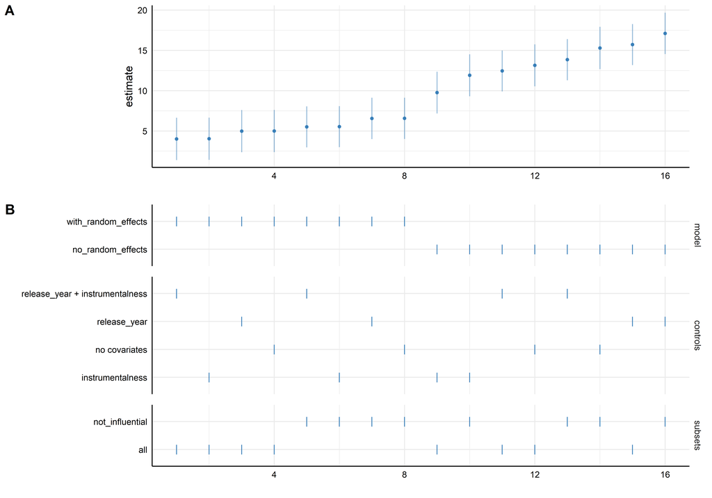

**Figure 7.** *Specification curve of the slope of valence in EDM.* Panel A: each dot is the estimated slope of valence (y-axis) in one of the 16 specifications, ordered from the lowest to the highest estimate (x-axis); the vertical lines are 95% confidence intervals. Panel B shows which decisions each specification corresponds to: “model” is whether the model includes random effects, “controls” the control variables, and “subsets” the sample (all tracks, or without the influential tracks). N = between 5,403 and 5,537 EDM tracks, depending on the sample.

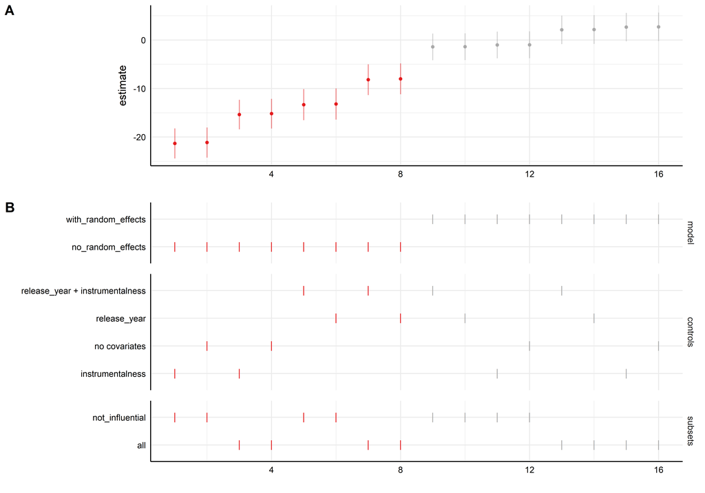

**Figure 8.** *Specification curve of the slope of valence in R&B.* Same structure as Figure 7, for R&B tracks. N = between 4,950 and 5,138 R&B tracks, depending on the sample.

In EDM (Figure 7), the slope of valence is positive in all 16 specifications: between 9.8 and 17.1 without random effects, and between 4.0 and 6.6 with them. In R&B (Figure 8), the conclusion depends on one decision. Without random effects, the slope is always negative (between -21.3 and -8.0): this is the “sad R&B songs are more popular” result of RR1. With random effects, it moves to between -1.4 and 2.7, and its confidence interval always includes zero. In both genres, the choice of controls and the removal of influential tracks change the estimates only a little. My conclusions are therefore robust, and the negative effect of valence in R&B was mostly a difference between old and recent playlists (Figure 6).

### Discussion

**Main result.** Musical positivity is not universally appealing: in my data, its association with popularity depends on the genre. But not in the way I expected. EDM is the only genre where happier songs are more popular, and this result is robust to all my data analysis decisions. In the five other genres, I find no evidence that valence is related to popularity once I compare songs within the same playlist and by the same artist. In particular, the striking result of my first analysis, that sad R&B songs are more popular, did not survive: it was mostly driven by the fact that old R&B playlists are both happier and less popular than recent ones. These results contradict the universalist hypothesis (H1), which predicted a positive effect of valence in every genre. They do not clearly support the contextualist hypothesis (H2) either: EDM stands out, but the global ANOVA test does not allow me to conclude that the slope of valence differs across genres, and I found no genre that rewards sad songs. Finally, all these effects are small: valence matters much less for popularity than the playlist a song is on, or the artist who sings it.

**Implications.** For researchers interested in the cultural evolution of music, like Mehr and Singh, my results suggest two things. First, the appeal of musical positivity does not seem to be a universal psychological constant: it only shows up in one genre, whose function is collective celebration. A cognitive theory of musical taste should therefore try to explain why the same acoustic feature matters in some listening contexts and not in others. One possibility is that musical appeal doesn’t rest on one psychological mechanism but on multiple ones (emotional regulation, social bonding, romantic bonding…), and different genres appeal to different mechanisms. Second, my analysis shows how easily large-scale streaming data can produce spurious cultural patterns: a striking genre-specific effect can turn out to be a difference between old and new playlists. Researchers who use this kind of data to test cognitive theories should take into account how the data is grouped, before drawing conclusions about human psychology.

**Limitations.** My results depend on several assumptions. First, my DAG assumes that danceability is a mediator. If it were instead a confounder (for instance, if some production styles make songs both danceable and happy-sounding), I should have controlled for it, and my estimates would be biased. Second, by comparing songs within the same playlist, I treat playlists as a source of grouping. But editors may put a song on a playlist *because* of its valence: in that case, part of the effect of valence goes through playlist placement, and my model removes it. My results should therefore be read as an answer to a narrower question: among songs offered to the same audience, are happier songs more popular? Third, all tracks in the dataset were selected because they appear on Spotify playlists. If being selected depends on both a song’s valence and its popularity, this selection could itself create or hide associations between the two.

**Future studies.** One possible next step to confirm our finding is an experiment. Our dataset has many confounds: artist reputation, marketing, playlist placement, the recommendation algorithm, etc., making it difficult to isolate the causal effect of valence itself. A cleaner test would be to take a set of tracks that are otherwise very similar (same genre, same tempo range, comparable production quality) and vary only their valence, by producing altered versions of the same track. Participants would then rate each track for appeal, and we would test whether the valence–appeal slope differs across genres. Given my results, the key prediction to test is whether valence increases appeal in EDM only, or also in other genres when the playlist context is held constant by design. If the EDM-specific effect shows up under those controlled conditions, we would have strong evidence that the pattern is about listener response to valence itself, and not about the platform or some other confound.

### References

Frith, S. (1996). *Performing rites: On the value of popular music*. Harvard University Press.

Mehr, S. A., Singh, M., Knox, D., Ketter, D. M., Pickens-Jones, D., Atwood, S., Lucas, C., Jacoby, N., Egner, A. A., Hopkins, E. J., Howard, R. M., Hartshorne, J. K., Jennings, M. V., Simson, J., Bainbridge, C. M., Pinker, S., O’Donnell, T. J., Krasnow, M. M., & Glowacki, L. (2019). Universality and diversity in human song. *Science*, *366*(6468), eaax0868. https://doi.org/10.1126/science.aax0868

Simonsohn, U., Simmons, J. P., & Nelson, L. D. (2020). Specification curve analysis. *Nature Human Behaviour*, *4*(11), 1208–1214. https://doi.org/10.1038/s41562-020-0912-z